# Load libraries

library(tidyverse)

# Import file and create data object

activity <- read_csv(“activity.csv”) sum(activity$steps, na.rm = TRUE)

# Designate values for aggregation

Steps = activity$steps Date = activity$date Interval = activity$interval SD <- aggregate(Steps~Date, data = activity, sum) SDI <- aggregate(Steps~Date + Interval, activity, sum)

# Calculate Total Number of Steps Taken per Day

# Histogram

ggplot(SD, aes( x = Date, weight = Steps))+ geom_histogram(binwidth = 1, fill = “blue”, color = “black”)+ labs(title = “Total Steps Taken Each Day”, x = “Date”, y = “Steps”)

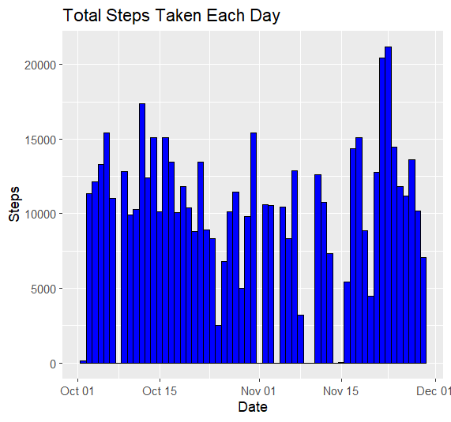

# Calculate and report mean and median of the total number of steps taken daily

#Mean

mean(SD$Steps, trim = 0, na.rm =TRUE)

hist(SD$Steps, breaks = 53, main = "Total Steps Daily", xlab = "steps") abline(v = mean(SD$Steps), col =“red”, lwd = 3) text( x = mean(SD$Steps), y = 5.5, labels = sprintf("Mean = %.2f", mean(SD$Steps)), col =“black”, pos = 4) # Median median(SD$Steps)

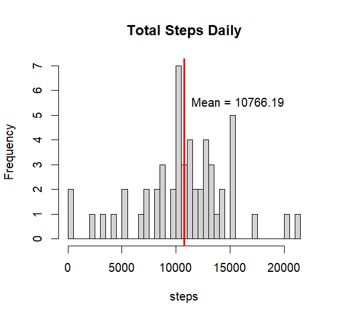

hist(SD$Steps, breaks = 53, main = "Total Steps Daily", xlab = "steps") abline(v = median (SD$Steps), col = “black”, lwd =5) text( x = median(SD$Steps), y = 5.5, labels = sprintf("Median = %.2f", median(SD$Steps)), col =“black”, pos = 4)

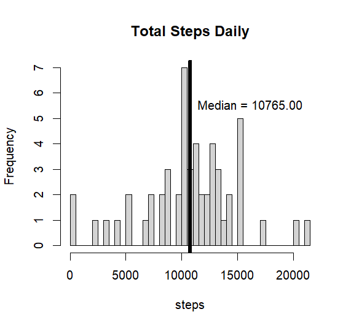

# Time series plot with 5 minute interval and average number of steps taken

# Average steps per interval across days

SD1 <- aggregate(Steps~Interval, data = activity, mean)

# Determine Range

range(SD1$Steps)

# Identify max mean steps and interval

Max1 <- SD1 [which.max(SD1$Steps),] x1 <- Max1$Interval y1 <- Max1$Steps

# Generate plot

plot(SD1$Interval, SD1$Steps, type = “l”, xlab = “Intervals (5 min)”, ylab = “Steps”, main = “Average Daily Step Activity”) abline( v = 835, col =“red”, lwd =2) text(x = 865, y = 190, labels = sprintf(“Max Avg Steps = %.2f at interval 835”, (y1)), adj = 0, cex =0.6)

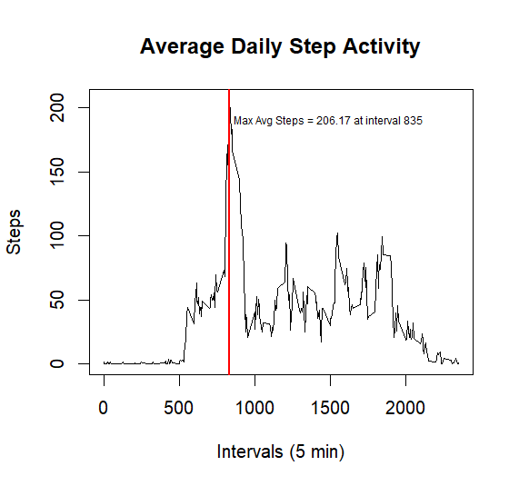

# Calculate total number of NA values

colSums(is.na(activity))

# What are their row numbers?

which(is.na(activity))

# First expand max.print

options(max.print = 3000) data.frame(which(is.na(activity))) which(is.na(activity)) # Identify and isolate NA

NA_ROWS <- activity %>% slice (c(1:288, 2017:2304, 8929:9216, 9793:10080, 11233:11520, 11521:11808, 12673:12960, 17281:17568))

# Preview overlay of isolated NA with mean activity values per interval

NA_OCT1 <- NA_ROWS[1:288,]

NA_Overlay_Oct1 <- cbind(SD1, NA_OCT1)

# Create a new dataset that is equal to the original dataset but with the missing data filled in

# Make duplicate activity dataset for imputing NAs

activity_1 <- activity

# Concatenate NA row segments

segments <- c(1:288, 2017:2304, 8929:9216, 9793:10080, 11233:11520, 11521:11808, 12673:12960, 17281:17568)

# Define NA replacement schema

Idx <- is.na(activity_1$steps) & seq_along(activity_1$steps) %in% segments

# Impute mean interval values into NAs

activity_1$steps <- replace(activity_1$steps, Idx, SD1$Steps[match(activity_1$interval[Idx], SD1$Interval)])

# Calculate and report mean and median of the total number of steps taken daily

SD2 <- aggregate(steps~date, data = activity_1, sum)

# Generate Total Daily Steps Histogram

ggplot(SD2, aes( x = date, weight = steps))+ geom_histogram(binwidth = 1, fill = “blue”, color = “black”)+ labs(title = “Total Steps Taken Each Day”, x = “Date”, y = “Steps”)

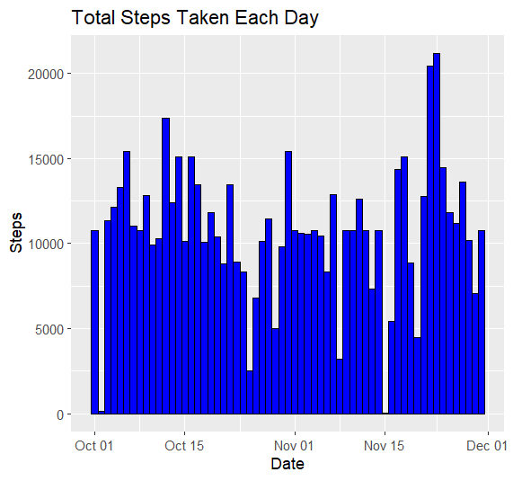

With imputed values added from activity_1

### Mean

mean(SD2$steps, trim = 0, na.rm =TRUE)

### Median

median(SD2$steps) # Generate new plots of mean and median total steps daily

hist(SD2$steps, breaks = 61, main = "Total Steps Daily", xlab = "steps") abline(v = mean(SD2$steps), col = “red”, lwd = 3) text( x = mean(SD2$steps), y = 5.5, labels = sprintf("Mean = %.2f", mean(SD2$steps)), col =“black”, pos = 4)

hist(SD2$steps, breaks = 61, main = "Total Steps Daily", xlab = "steps") abline(v = median (SD2$steps), col = “black”, lwd =5) text( x = median(SD2$steps), y = 5.5, labels = sprintf("Median = %.2f", median(SD2$steps)), col =“black”, pos = 4)

[figure not shown]

With imputed values from activity_1

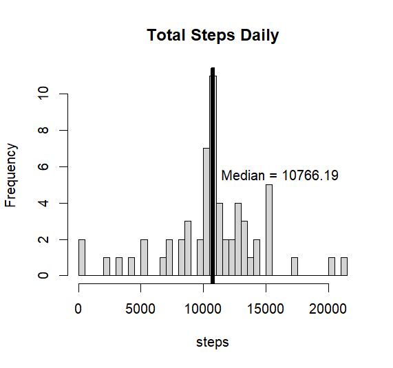

With imputed values from activity_1

### Generate weekday daily step activity subset from activity_1

weekday <- activity_1 %>% slice (c(1:1440,2017:3457, 4033:3457, 4033:5473, 6049:7488, 8066:9505, 10082:11521, 12098:13536, 14113:15552, 16129:17568))

### Generate weekend daily step activity subset from activity_1

weekend <- activity_1 %>% slice (c(1441:2016, 3458:4032, 5474:6048, 7489:8065, 9506:10081, 11522:12097, 13537:14112, 11553:16128))

### Designate values for aggregate and plot generation

WD_Steps = weekday$steps WD_Interval = weekday$interval WE_Steps = weekend$steps WE_Interval = weekend$interval

# Obtain means per interval for weekdays

SD_WD <- aggregate(WD_Steps~WD_Interval, data=weekday, mean)

# Obtain means per interval for weekends

SD_WE <- aggregate(WE_Steps~WE_Interval, data=weekday, mean)

Max2 <- SD_WD [which.max(SD_WD$WD_Steps),] x2 <- Max2$WD_Steps y2 <- Max2$WD_Interval

Max3 <- SD_WE [which.max(SD_WE$WE_Steps),] x3 <- Max3$WE_Steps y3 <- Max3$WE_Interval

# For weekday vs weekend time series

# Generate plot

par(mfrow=c(2,1)) par(mar =c(4,4,2,2))

```
plot(SD_WD,
 type = "l",
 xlab = "Intervals (5min)",
 ylab = "Steps",
 main = "Weekday")
```

abline( v = 835, col =“red”, lwd =2) text(x = 865, y = 190, labels = sprintf(“Max Steps = %.2f at inteval 835”, (x2)), adj = 0, cex =0.6)

plot(SD_WE, type =“l”, xlab = “Intervals (5 min)”, ylab = “Steps”, main = “Weekend”) abline( v = 855, col =“red”, lwd =2) text(x = 865, y = 150, labels = sprintf(“Max Steps = %.2f at interval 855”, (x3)), adj = 0, cex = 0.6)

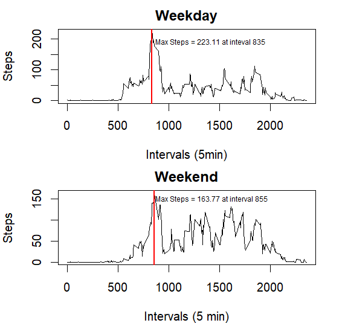

With imputed values from activity_1